# Road Accident Analysis

### prepared by Gordon Tang

Purpose of this road accident analysis is to understand the data of road accidents and assist of allocating resource to reduce road accidents.

## Top 10 Highest Number of Road Accidents by Region

```
LGA_NAME
MELBOURNE       3318
CASEY           2277
GEELONG         2034
DANDENONG       1891
HUME            1732
YARRA RANGES    1711
BRIMBANK        1709
MONASH          1613
WHITTLESEA      1594
MORELAND        1563
Name: LGA_NAME, dtype: int64
```

[figure not shown]

```python
import seaborn as sns
import pandas as pd
import numpy as np
import matplotlib.pyplot as plt
acc_infor = pd.read_csv('ACCIDENT.csv')
acc_loc = pd.read_csv('ACCIDENT_LOCATION.csv')
node = pd.read_csv('NODE.csv')
mer_acc_infor_node = acc_infor.merge(node, on='ACCIDENT_NO', how='left')
series = mer_acc_infor_node[['LGA_NAME']]\
    .groupby(['LGA_NAME']).LGA_NAME.count().sort_values(ascending=False)

seriesh = series.head(10)
areas = seriesh.keys()

sns.set_style('darkgrid')
x = areas
y = seriesh.values
plt.figure(figsize=(16, 6))
sns.barplot(x, y)\
    .set_title("Top 10 of highest Road Accidents Region")
plt.xlabel("Name of Region", size=10)
plt.ylabel("Number of Accident", size=10)
print(seriesh)
plt.show()
```

The bar chart shows that Melbourne has the highest number of road accidents,

followed by Casey, which is in greater Melbourne area.

The authority, therefore, should invest most of their resource to reduce chances of accidents.

## Least 10 of Road Accidents by Region

```
LGA_NAME
                             35
(MOUNT HOTHAM)               16
(LAKE MOUNTAIN)               8
(FALLS CREEK)                 8
(MOUNT BULLER)                7
QUEENSCLIFFE                  4
(MOUNT BAW BAW)               4
MOUNT BULLER ALPINE RESOR     1
(MOUNT STIRLING)              1
(FRENCH ISLAND)               1
Name: LGA_NAME, dtype: int64
```

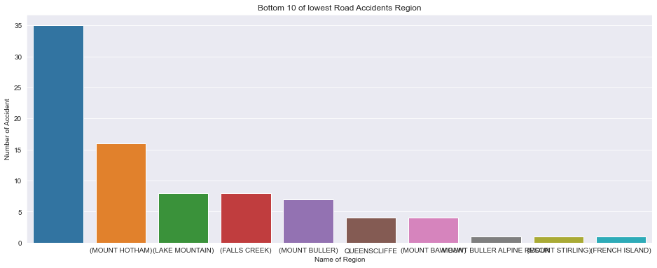

```python
seriest = series.tail(10)
areas = seriest.keys()
sns.set_style('darkgrid')
x = areas
y = seriest.values
plt.figure(figsize=(16, 6))
sns.barplot(x, y)\
    .set_title("Bottom 10 of lowest Road Accidents Region")
plt.xlabel("Name of Region", size=10)
plt.ylabel("Number of Accident", size=10)
print(seriest)
plt.show()
```

In contrast, Regional areas have significant less accidents than the metropolitan areas. The government ma consider invest less resources to those areas.

## Top 10 Incidents by code

```
DCA_CODE
130    9783
121    4756
110    3624
171    3042
113    2512
174    2470
173    2145
100    1827
120    1723
181    1643
Name: DCA_CODE, dtype: int64
```

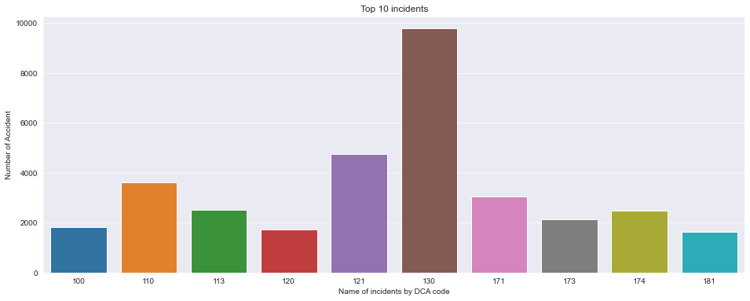

```python
series_dca = acc_infor[['DCA_CODE']]\
    .groupby(['DCA_CODE']).DCA_CODE.count().sort_values(ascending=False)
top10_series_dca = series_dca.head(10)
dca_code = top10_series_dca.keys()
x = dca_code
y = top10_series_dca.values
plt.figure(figsize=(16, 6))
sns.barplot(x, y)\
    .set_title("Top 10 incidents")
plt.xlabel("Name of incidents by DCA code", size=10)
plt.ylabel("Number of Accident", size=10)
print(top10_series_dca)
plt.show()
```

There are 10 common accidents on the road :

| DCA_CODE | Description |
| --- | --- |
| 130 | Rear end (vehicles in same lane) |
| 121 | Right through |
| 110 | Cross traffic (intersections only) |
| 171 | Left off carriageway into object / parked vehicle |
| 113 | Right near (intersections only) |
| 174 | Out of control on carriageway (on straight) |
| 173 | Right off carriageway into object/parked vehicle |
| 100 | Pedestrian near side hit by vehicle from the right |
| 120 | Head on (not overtaking) |
| 181 | Off right bend into object/parked vehicle |

The most common incident is car Crashing from the back.

Interestingly, 4 out of top 10 incidents are related to turn right, I believe Left-hand traffic is the cause,

it would have more "turnning left accidents" by the same token of Left-hand traffic.

The transport department may place more signs or traffic lights to mitigage the risk of turnning right accidents.

It is also to remind drivers to keep distance between vehicles.

## Accidents Distribution on Weekday by code

```
DAY_OF_WEEK
6    8361
5    8186
4    8000
3    7721
2    7488
1    7076
7    6168
0    1258
Name: DAY_OF_WEEK, dtype: int64
```

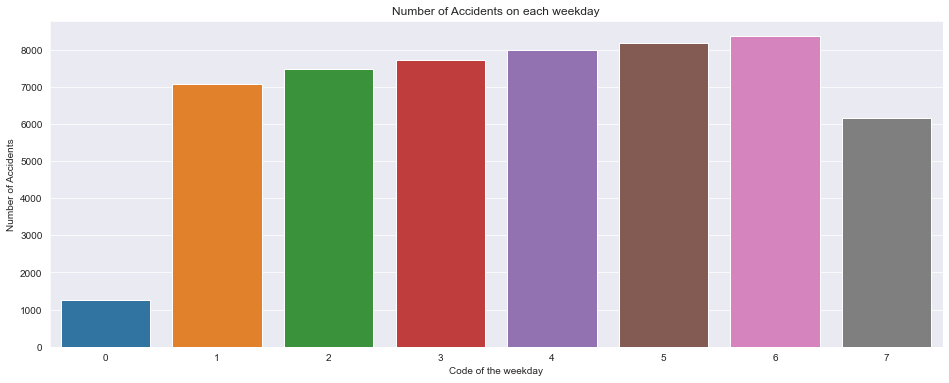

```python
number_of_acci_by_weekday = acc_infor\
    .groupby(['DAY_OF_WEEK']).DAY_OF_WEEK.count().sort_values(ascending=False)
weekday_code = number_of_acci_by_weekday.keys()
x = weekday_code
y = number_of_acci_by_weekday.values
plt.figure(figsize=(16, 6))
sns.barplot(x, y)\
    .set_title("Number of Accidents on each weekday")
plt.xlabel("Code of the weekday", size=10)
plt.ylabel("Number of Accidents", size=10)
print(number_of_acci_by_weekday)
plt.show()
```

| Weekday code | Weekday Description |
| --- | --- |
| 0 | Sunday |
| 1 | Monday |
| 2 | Tuesday |
| 3 | Wednesday |
| 4 | Thursday |
| 5 | Friday |
| 6 | Saturday |

Except Sunday, accidents are fairly distributed on all other days. Department may reduce their resource spending on Sunday.

## Number of Accidents by speed zone

```
SPEED_ZONE
60     18141
50      8986
100     8290
80      7631
70      3607
999     3249
40      3045
110      590
888      371
90       188
30        83
777       69
75         8
Name: SPEED_ZONE, dtype: int64
```

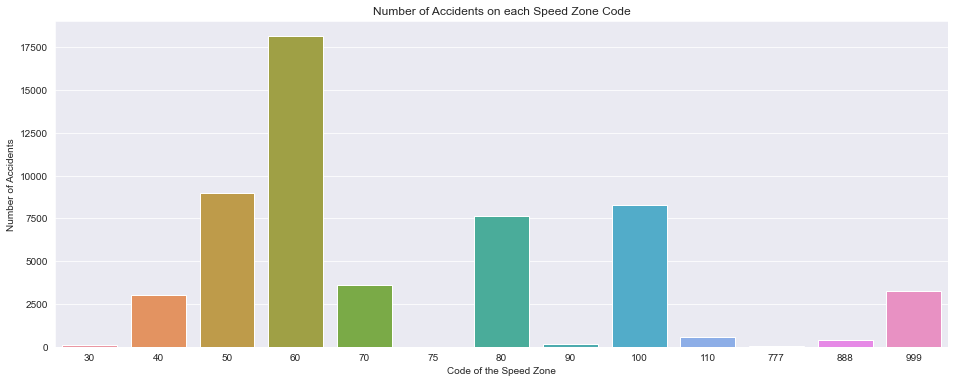

```python
number_of_accidents_on_speed_zone = acc_infor\
    .groupby(['SPEED_ZONE']).SPEED_ZONE.count().sort_values(ascending=False)
speed_zone_code = number_of_accidents_on_speed_zone.keys()
x = speed_zone_code
y = number_of_accidents_on_speed_zone.values
plt.figure(figsize=(16, 6))
sns.barplot(x, y)\
    .set_title("Number of Accidents on each Speed Zone Code")
plt.xlabel("Code of the Speed Zone", size=10)
plt.ylabel("Number of Accidents", size=10)
print(number_of_accidents_on_speed_zone)
plt.show()
```

| Speed limited code | Speed limited Description |
| --- | --- |
| 040 | 40 km/hr |
| 050 | 50 km/hr |
| 060 | 60 km/hr |
| 075 | 75 km/hr |
| 080 | 80 km/hr |
| 090 | 90 km/hr |
| 100 | 100 km/hr |
| 110 | 110 km/hr |
| 777 | Other speed limit |
| 888 | Camping grounds |
| 999 | off road 999 Not known |

Most of the road are speed limited at 60, it is thus we have most of data showing speed limited zone has most of the accidents.